# 과제#4 - MLE 응용

### 통계대학원 202STG18 이재빈

```r
library(tidyverse)
library(optimx)
```

# Part1. Challenger 우주왕복선 O-ring 고장확률예측

- Logistic -> logit
- Normal -> probit
- Gompertz -> gompit

```r
oring <- read.csv("oring.csv", na.strings="*")
names(oring) <- c("id", "n", "y", "x")
oring<-data.frame(x=oring$x, y=oring$y, n=oring$n)
oring<-na.omit(oring)
```

## (a) AIC로부터 최적 예측모형 구하기

```r
# Inf 처리 위한 초기값 설정
p<-rep(0,length(oring$y))
for(i in 1:length(oring$y)){
  if(oring$y[i]==0){
    p[i]<-0.1
  }else if(oring$y[i]==1){
    p[i]<-0.5
  }else{ p[i]<-0.9 } }
```

```r
# G(z)
mylogit<- glm(cbind(y,6-y) ~ x, data=oring, family=binomial(link = "logit"))
myprobit<- glm(cbind(y,6-y) ~ x, data=oring, family=binomial(link = "probit"))
mygompit<- glm(cbind(y,6-y) ~ x, data=oring, family=binomial(link = "cloglog"))
```

```r
# alpha, beta
par1 <- mylogit$coeff
par2 <- myprobit$coeff
par3 <- mygompit$coeff
par1; par2; par3
```

**(Intercept)**

5.08497723236888

**x**

-0.11560116666022

**(Intercept)**

2.23452259704643

**x**

-0.0554984149180786

**(Intercept)**

4.71422003697337

**x**

-0.110763095632717

```r
# G(a+bx)
trans <- function(par,x) par[1]+par[2]*x[,1]
p.logit <- function(par,x) 1/(1+exp(-trans(par,x)))
p.normal<-function(par,x) pnorm(trans(par,x))
p.gomp<-function(par,x) 1-exp(-exp(trans(par,x)))

q.gomp<- function(p) log(-log(1-p))
```

```r
# log-likelihood
logit.loglik <- function(par,x) -2*sum(x[,2]*log(p.logit(par,x)) + (x[,3]-x[,2])*log(1-p.logit(par,x)))
norm.loglik <- function(par,x) -2*sum(x[,2]*log(p.normal(par,x)) + (x[,3]-x[,2])*log(1-p.normal(par,x)))
gomp.loglik <- function(par,x) -2*sum(x[,2]*log(p.gomp(par,x)) + (x[,3]-x[,2])*log(1-p.gomp(par,x)))
```

```r
# MLE
logit.mle<-optimx(par=par1, fn=logit.loglik, x=oring)
norm.mle<-optimx(par=par2, fn=norm.loglik, x=oring)
gomp.mle<-optimx(par=par3, fn=gomp.loglik, x=oring)
```

```r
# AIC
AIC.list <- rbind(logit.mle$value[1], norm.mle$value[1], gomp.mle$value[1])

# AIC table
AIC.table <- cbind(AIC.list, rep(4,3), AIC.list+rep(4,3))
colnames(AIC.table) <- c("-2loglik","2p","AIC")
rownames(AIC.table) <- c("logit","probit","gompit")

AIC.table
names(which.min(AIC.table[,3]))
```

|  | -2loglik | 2p | AIC |
| --- | --- | --- | --- |
| logit | 60.39634 | 4 | 64.39634 |
| probit | 60.62131 | 4 | 64.62131 |
| gompit | 60.32405 | 4 | 64.32405 |

'gompit'

AIC가 64.324인 Gompertz 모형이 최적 예측모형이다.

## (b) 적절한 예측모형 선택하기

### H0: beta=0 vs H1: beta != 0

```r
par4 <- c(mean(q.gomp(p)),0); par4
gomp.opt2<-hjn(par=par4, fn=gomp.loglik, x=oring, bdmsk=c(1,0))
print(gomp.opt2)
```

1. -1.57262508475702

2. 0

```
$par
[1] -2.696498  0.000000

$value
[1] 66.54037

$counts
[1] 57 NA

$convergence
[1] 0
```

```r
# AIC table
AIC.table2 <- matrix(c(gomp.opt2$value, gomp.mle$value[1],
                    c(2,4), rep(0,2)), ncol=3)
AIC.table2[,3]<-AIC.table2[,1]+AIC.table2[,2]
colnames(AIC.table2) <- c("-2loglik","2p","AIC")
rownames(AIC.table2) <- c("H0","H1")

AIC.table2
names(which.min(AIC.table2[,3]))
```

|  | -2loglik | 2p | AIC |
| --- | --- | --- | --- |
| H0 | 66.54037 | 2 | 68.54037 |
| H1 | 60.32405 | 4 | 64.32405 |

'H1'

H1에서 AIC값이 더 작기 때문에 beta != 0 인 모형이 적절한 예측모형이다.

## (c) 모수들의 추정오차, 신뢰구간 구하기

```r
gomp.opt<-optim(par=par3, fn=gomp.loglik, x=oring, method="Nelder-Mead", hessian = TRUE)
gomp.hess<-sqrt(c(solve(gomp.opt$hessian)[1,1], solve(gomp.opt$hessian)[2,2])); gomp.hess
```

1. 1.98119753059996

2. 0.030809812720911

```r
CI.alpha<-c(gomp.opt$par[1] - 1.96*gomp.hess[1], gomp.opt$par[1] + 1.96*gomp.hess[1])
CI.beta<-c(gomp.opt$par[2] - 1.96*gomp.hess[2], gomp.opt$par[2] + 1.96*gomp.hess[2])

cat("CI.alpha: [", CI.alpha[1], ",", CI.alpha[2], "] \n")
cat("CI.beta: [", CI.beta[1], ",", CI.beta[2], "]")
```

```
CI.alpha: [ 0.8310729 , 8.597367 ]
CI.beta: [ -0.1711503 , -0.05037586 ]
```

## (d) x*=31F

```r
par31<-gomp.opt$par
p31<-p.gomp(par31, as.matrix(31))
cat("p(31) = ", p31, "\n") # o-ring의 고장 확률
cat("E(31) = ", 6*p31) # o-ring의 고장 개수
```

```
p(31) =  0.9726399
E(31) =  5.835839
```

- E(y|31)이 5.83이므로 6개의 O-ring중 거의 모든 O-ring이 고장난다고 볼 수 있다.
- 따라서 기존의 자료와 비교했을 때 Temperature가 낮을수록 더 고장이 잘 난다고 생각할 수 있다.

# Part2. Leukemia 환자 생존수명 예측

```r
leukemia<-read.csv("leukemia.csv", header=TRUE)
colnames(leukemia)<-c("y", "x")
```

## (a) (lny, lnx)

### LSE에 대한 잔차의 Normal Q-Q Plot, Gompertz Q-Q Plot 그리기

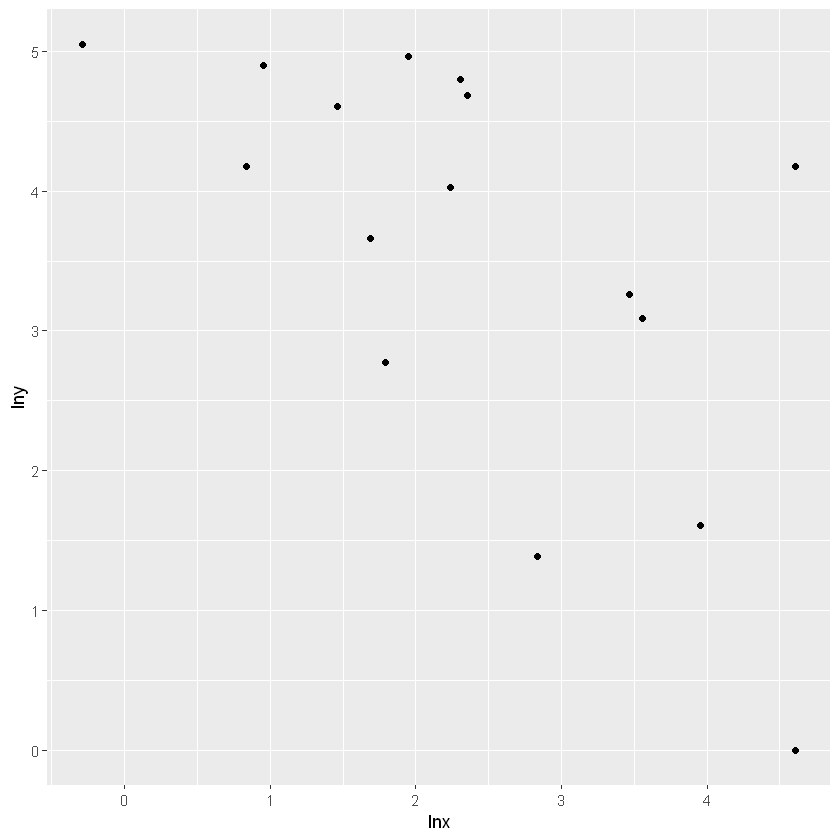

```r
# (lny, lnx) 산점도
leukemia<-as.tibble(leukemia) %>% mutate(lny=log(y),lnx=log(x))
ggplot(leukemia,aes(lnx,lny))+geom_point()
```

```r
# LSE
lm_leuk<-lm(lny~lnx,data=leukemia)
alphahat<-lm_leuk$coefficients[1]
betahat<-lm_leuk$coefficients[2]
c(alphahat,betahat)
```

**(Intercept)**

5.42539580261603

**lnx**

-0.817800667958474

```r
# residual Q-Q Plot
leukemia<-leukemia %>% mutate(e=lny-alphahat-betahat*lnx,r=rank(e),
                              probit=qnorm(r/(nrow(leukemia)+1)),
                              gompit=log(-log(1-r/(nrow(leukemia)+1))))
```

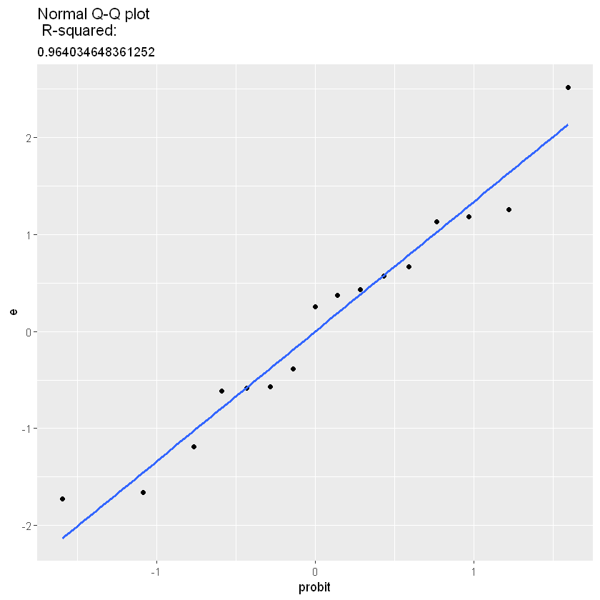

```r
ggplot(leukemia,aes(probit,e))+geom_point()+geom_smooth(method="lm",se=F)+
  ggtitle("Normal Q-Q plot \n R-squared:", summary(lm(e~probit, data=leukemia))$r.squared)
```

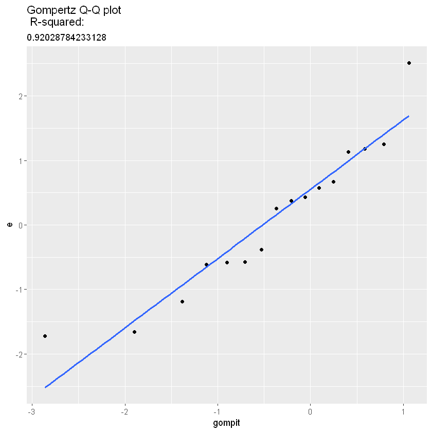

```r
ggplot(leukemia,aes(gompit,e))+geom_point()+geom_smooth(method="lm",se=F)+
  ggtitle("Gompertz Q-Q plot \n R-squared:", summary(lm(e~gompit, data=leukemia))$r.squared)
```

Normal 분포의 R-squared 값이 더 크기 때문에, 오차의 분포는 e ~ N(0,1) 임을 알 수 있다.

## (b) log-normal 모형

```r
lnleuk <- data.frame(lnx = leukemia$lnx, lny = leukemia$lny)
```

```r
trans2<- function(par,x)  (x[,2]-par[1]-par[2]*x[,1])/par[3]
norm.loglik2<- function(par,x) -2*sum( -trans2(par,x)^2/2 -0.5*log(2*pi*(par[3]^2)))
```

```r
par5<-lm(lny~lnx, data=leukemia)$coeff
par5<-c(par5, lm(e~probit, data=leukemia)$coeff[2])
par5 #initial values
```

**(Intercept)**

5.42539580261603

**lnx**

-0.817800667958474

**probit**

1.33705190964411

```r
lognorm.opt<-optimx(par=par5, fn=norm.loglik2, x=lnleuk); lognorm.opt
```

|  | X.Intercept. | lnx | probit | value | fevals | gevals | niter | convcode | kkt1 | kkt2 | xtime |
| --- | --- | --- | --- | --- | --- | --- | --- | --- | --- | --- | --- |
| Nelder-Mead | 5.425380 | -0.8177778 | 1.157902 | 53.23033 | 86 | NA | NA | 0 | NA | NA | 0.03 |
| BFGS | 5.425399 | -0.8177905 | 1.158062 | 53.23033 | 31 | 6 | NA | 0 | NA | NA | 0.00 |

```r
lognorm.mle<-lognorm.opt[1,1:3]
colnames(lognorm.mle)<-c("alpha", "beta", "sigma"); rownames(lognorm.mle)<-"MLE"
lognorm.mle
```

|  | alpha | beta | sigma |
| --- | --- | --- | --- |
| MLE | 5.42538 | -0.8177778 | 1.157902 |

```r
cat("AIC of log-normal : ", lognorm.opt$value[1] + 6)
```

```
AIC of log-normal :  59.23033
```

## (c) log-Gompertz 모형

```r
trans3<- function(par,x) (x[,2]-par[1]-par[2]*x[,1]+0.57721)/par[3]
gomp.loglik2 <- function(par,x)
  -2*sum(log(1/par[3]*exp(-exp(trans3(par,x)) + trans3(par,x))))
```

```r
par6<-lm(lny~lnx, data=leukemia)$coeff
par6<-c(par6, lm(e~gompit, data=leukemia)$coeff[2])
par6 #initial values
```

**(Intercept)**

5.42539580261603

**lnx**

-0.817800667958474

**gompit**

1.07450249576402

```r
loggomp.opt<-optimx(par=par6, fn=gomp.loglik2, x=lnleuk, hessian = TRUE); loggomp.opt
# hessian 값이 출력되지 않습니다...
```

|  | X.Intercept. | lnx | gompit | value | fevals | gevals | niter | convcode | kkt1 | kkt2 | xtime |
| --- | --- | --- | --- | --- | --- | --- | --- | --- | --- | --- | --- |
| Nelder-Mead | 5.723224 | -0.4768700 | 0.9783357 | 53.44568 | 96 | NA | NA | 0 | NA | NA | 0.00 |
| BFGS | 5.723482 | -0.4769899 | 0.9784933 | 53.44568 | 41 | 13 | NA | 0 | NA | NA | 0.02 |

```r
loggomp.mle<-loggomp.opt[1,1:3]
colnames(loggomp.mle)<-c("alpha", "beta", "sigma"); rownames(loggomp.mle)<-"MLE"
loggomp.mle
```

|  | alpha | beta | sigma |
| --- | --- | --- | --- |
| MLE | 5.723224 | -0.47687 | 0.9783357 |

```r
cat("AIC of log-Gompertz : ", loggomp.opt$value[1] + 6)
```

```
AIC of log-Gompertz :  59.44568
```

## (d) log-Gompertz 모수들의 추정오차, 신뢰구간 구하기

```r
loggomp.opt$hessian
```

```r
loggomp.hess<-rep(0,3)
for(i in 1:3) loggomp.hess[i]<-sqrt(solve(loggomp.opt$hessian)[i,i])
loggomp.hess<-t(as.matrix(loggomp.hess))
colnames(loggomp.hess)<-c("alpha", "beta", "sigma"); rownames(loggomp.hess)<-"SE"
loggomp.hess
```

[output not shown]

```r
cat("CI.alpha: [", loggomp.mle[1] - 1.96*loggomp.hess[1], ",", loggomp.mle[1] + 1.96*loggomp.hess[1], "]")
cat("CI.beta: [", loggomp.mle[2] - 1.96*loggomp.hess[2], ",", loggomp.mle[2] + 1.96*loggomp.hess[2], "]")
cat("CI.sigma: [", loggomp.mle[3] - 1.96*loggomp.hess[3], ",", loggomp.mle[3] + 1.96*loggomp.hess[3], "]")
```

[output not shown]

## (e) log-normal vs log-Gompertz

```r
AIC.table3<-matrix(c(lognorm.opt$value[1], loggomp.opt$value[1],
                    rep(6,2), rep(0,2)), ncol=3)
AIC.table3[,3]<-AIC.table3[,1]+AIC.table3[,2]
colnames(AIC.table3)<-c("-2loglik", "2p", "AIC")
rownames(AIC.table3)<-c("log-normal", "log-Gompertz")

AIC.table3
names(which.min(AIC.table3[,3]))
```

|  | -2loglik | 2p | AIC |
| --- | --- | --- | --- |
| log-normal | 53.23033 | 6 | 59.23033 |
| log-Gompertz | 53.44568 | 6 | 59.44568 |

'log-normal'

- log-normal모형에서 AIC가 더 작기 때문에 log-normal모형이 더 적절하다고 할 수 있다.
- 하지만 일반적으로, 수명분포는 Gompertz 분포를 따른다고 알려져 있다.
- (e)의 결과가 이상하다고 생각할 수 있겠으나 문제 (f)를 풀어보면  
  극단적인 값에서는 Gompertz 분포를 더 따른다는 것을 확인할 수 있다.

## (f) x*=20인 백혈병 환자의 생존확률 구하기

```r
# 1년, 2년, 5년 = 52주, 104주, 260주
life <- matrix(c(rep(log(20),3), log(c(52,104,260))), ncol=2)
```

```r
life.lognorm<- 1-pnorm(trans2(as.numeric(lognorm.mle), life))
life.loggomp<- exp(-exp(trans3(as.numeric(loggomp.mle), life)))
```

```r
lifeexp<-matrix(c(52,104,260, life.lognorm, life.loggomp), ncol=3)
colnames(lifeexp)<-c("t", "log-normal", "log-Gompertz")
lifeexp
```

| t | log-normal | log-Gompertz |
| --- | --- | --- |
| 52 | 0.19971188 | 0.280844111 |
| 104 | 0.07475358 | 0.075834872 |
| 260 | 0.01278728 | 0.001387626 |

# Part3. Q-Q Plot을 이용한 Weibull 분포 모수추정

```r
steel <- read.csv("table1.csv", header=T)
colnames(steel) <- c("x", "exp", "obs", "norm")

cotton <- read.csv("table3.csv", header=T)
colnames(cotton) <- c("x", "exp", "obs", "pears")
```

## (a) Histogram

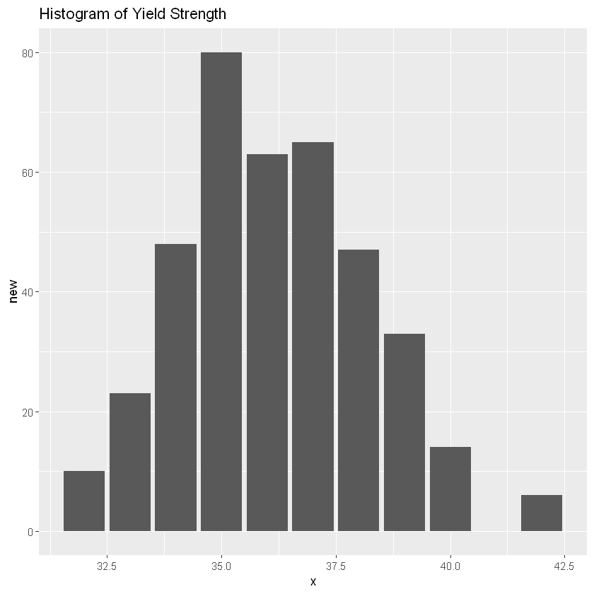

```r
steel<-as.tibble(steel) %>% mutate(new=obs-lag(obs))
steel[1,"new"]<-steel[1,"obs"]
ggplot(steel,aes(x,new))+geom_histogram(stat="identity")+ggtitle("Histogram of Yield Strength")
```

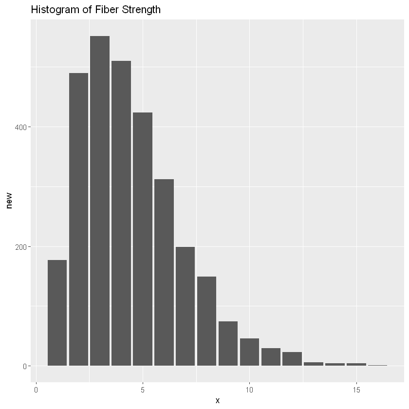

```r
cotton<-as.tibble(cotton) %>% mutate(new=obs-lag(obs))
cotton[1,"new"]<-cotton[1,"obs"]
ggplot(cotton,aes(x,new))+geom_histogram(stat="identity")+ggtitle("Histogram of Fiber Strength")
```

- 히스토그램을 통해 왼쪽으로 살짝 치우치고 오른쪽으로 꼬리를 갖는 분포임을 알 수 있다.
- 따라서 EVD는 Gumbel, Weibull, Frechet 분포를 따를 가능성이 높다고 생각한다.

## (b) 3-parameter Weibull 분포의 모수 추정

```r
n1<-389
n2<-3000
```

## 방법1

$\alpha$값 변화 -> $x$축 $[-ln(1-p_r)]^{1/\alpha}$, $y$축 $X_{(r)}$인 Q-Q plot

```r
lm1_steel<-function(a) {
  steel_new<-steel %>% filter(x>a) %>% mutate(pr=obs/(n1+1),probit=(-log(1-pr))^(1/a))
  lm1<-lm(x~probit,data=steel_new)
  intercept1<-as.numeric(format(summary(lm1)$coefficients[1],digits=4))
  slope1<-as.numeric(format(summary(lm1)$coefficients[2],digits=4))
  rsqr1<-summary(lm1)$r.squared
  return(list(rsqr1,intercept1,slope1))
}

lm1_cotton<-function(a) {
  cotton_new<-cotton %>% filter(x>a) %>% mutate(pr=obs/(n2+1),probit=(-log(1-pr))^(1/a))
  lm3<-lm(x~probit,data=cotton_new)
  intercept3<-as.numeric(format(summary(lm3)$coefficients[1],digits=4))
  slope3<-as.numeric(format(summary(lm3)$coefficients[2],digits=4))
  rsqr3<-summary(lm3)$r.squared
  return(list(rsqr3,intercept3,slope3))
}
```

```r
interval<-0.01
a1<-seq(interval,10,by=interval)
Rsquared1<-rep(NA,length(a1))
Rsquared3<-rep(NA,length(a1))
```

```r
for (i in 1:length(a1)) {
  Rsquared1[i]<-lm1_steel(a1[i])[[1]]
  Rsquared3[i]<-lm1_cotton(a1[i])[[1]]
}
```

```r
alpha_steel<-interval*which.max(Rsquared1)
a_steel<-lm1_steel(alpha_steel)[[2]]
b_steel<-lm1_steel(alpha_steel)[[3]]
```

```r
alpha_cotton<-interval*which.max(Rsquared3)
a_cotton<-lm1_cotton(alpha_cotton)[[2]]
b_cotton<-lm1_cotton(alpha_cotton)[[3]]
```

```r
steel_new<-steel %>% mutate(pr=obs/(n1+1),probit=(-log(1-pr))^(1/alpha_steel))
cotton_new<-cotton %>% mutate(pr=obs/(n2+1),probit=(-log(1-pr))^(1/alpha_cotton))
```

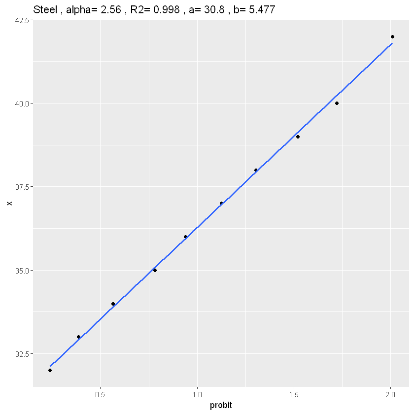

```r
ggplot(steel_new,aes(probit,x))+
  geom_point()+
  geom_smooth(method="lm",se=F)+
  ggtitle(paste("Steel",",","alpha=",alpha_steel,",",
                "R2=",format(Rsquared1[which.max(Rsquared1)],digits=3),",",
                "a=",a_steel,",","b=",b_steel))
```

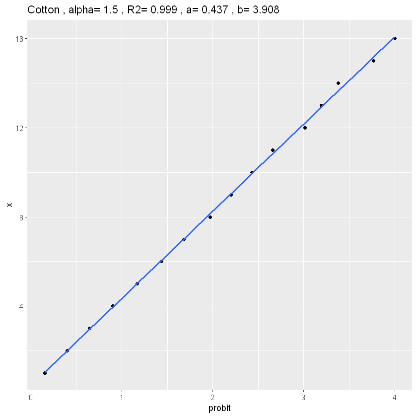

```r
ggplot(cotton_new,aes(probit,x))+
  geom_point()+
  geom_smooth(method="lm",se=F)+
  ggtitle(paste("Cotton",",","alpha=",alpha_cotton,",",
                "R2=",format(Rsquared3[which.max(Rsquared3)],digits=3),",",
                "a=",a_cotton,",","b=",b_cotton))
```

## 방법2

$a$값 변화 -> $x$축 $ln[-ln(1-p_r)]$, $y$축 $ln(X_{(r)}-a)$인 Q-Q Plot

```r
lm2_steel<-function(aaa) {
  steel_new<-steel %>% filter(x>aaa) %>% mutate(pr=obs/(n1+1),probit=log(-log(1-pr)))
  lm1<-lm(log(x-aaa)~probit,data=steel_new)
  intercept1<-as.numeric(format(summary(lm1)$coefficients[1],digits=4))
  slope1<-as.numeric(format(summary(lm1)$coefficients[2],digits=4))
  rsqr1<-summary(lm1)$r.squared
  return(list(rsqr1,intercept1,slope1))
}

lm2_cotton<-function(aaa) {
  cotton_new<-cotton %>% filter(x>aaa) %>% mutate(pr=obs/(n2+1),probit=log(-log(1-pr)))
  lm3<-lm(log(x-aaa)~probit,data=cotton_new)
  intercept3<-as.numeric(format(summary(lm3)$coefficients[1],digits=4))
  slope3<-as.numeric(format(summary(lm3)$coefficients[2],digits=4))
  rsqr3<-summary(lm3)$r.squared
  return(list(rsqr3,intercept3,slope3))
}
```

```r
initial1<-0.1
a2<-seq(initial1,32,by=initial1)
Rsquared11<-rep(NA,length(a2))

initial2<-0.01
a3<-seq(initial2,1,by=initial2)
Rsquared33<-rep(NA,length(a3))
```

```r
for (i in 1:length(a2)) {
  Rsquared11[i]<-lm2_steel(a2[i])[[1]]
}

for (j in 1:length(a3)) {
  Rsquared33[j]<-lm2_cotton(a3[j])[[1]]
}
```

```r
a_steel1<-initial1*which.max(Rsquared11)
mu_steel1<-lm2_steel(a_steel1)[[2]]
sigma_steel1<-lm2_steel(a_steel1)[[3]]
```

```r
a_cotton3<-initial2*which.max(Rsquared33)
mu_cotton3<-lm2_cotton(a_cotton3)[[2]]
sigma_cotton3<-lm2_cotton(a_cotton3)[[3]]
```

```r
steel_new1<-steel %>% filter(x>a_steel1) %>% mutate(pr=obs/(n1+1),probit=log(-log(1-pr)))
cotton_new3<-cotton %>% filter(x>a_cotton3) %>% mutate(pr=obs/(n2+1),probit=log(-log(1-pr)))
```

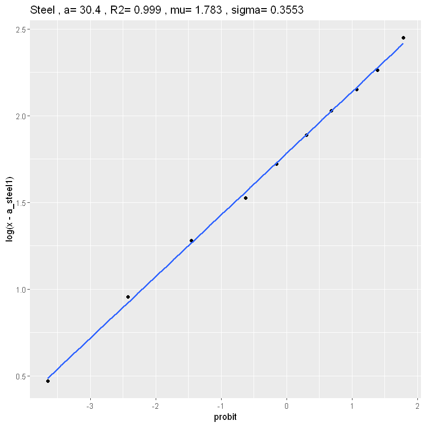

```r
ggplot(steel_new1,aes(probit,log(x-a_steel1)))+
  geom_point()+
  geom_smooth(method="lm",se=F)+
  ggtitle(paste("Steel",",","a=",a_steel1,",",
                "R2=",format(Rsquared11[which.max(Rsquared11)],digits=3),",",
                "mu=",mu_steel1,",","sigma=",sigma_steel1))
```

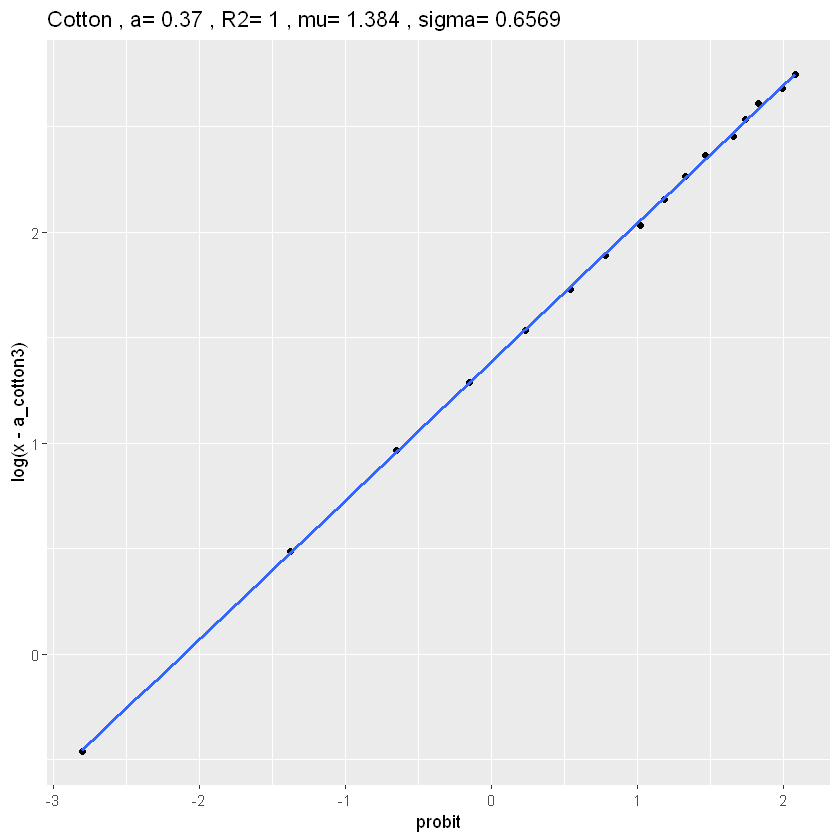

```r
ggplot(cotton_new3,aes(probit,log(x-a_cotton3)))+
  geom_point()+
  geom_smooth(method="lm",se=F)+
  ggtitle(paste("Cotton",",","a=",a_cotton3,",",
                "R2=",format(Rsquared33[which.max(Rsquared33)],digits=3),",",
                "mu=",mu_cotton3,",","sigma=",sigma_cotton3))
```

```r
# 추가 확인: mu=lnb, sigma=1/alpha

c(log(b_steel),mu_steel1,1/alpha_steel,sigma_steel1) # steel
c(log(b_cotton),mu_cotton3,1/alpha_cotton,sigma_cotton3) # cotton
```

1. 1.70055750580158

2. 1.783

3. 0.390625

4. 0.3553

1. 1.36302573418054

2. 1.384

3. 0.666666666666667

4. 0.6569

## (c) MLE 모수 추정

```r
steelfunc<-function(theta) {
  steel<-steel %>% mutate(Fx=1-exp(-((x-theta[1])/theta[2])^theta[3]),pitheta=Fx-lag(Fx))
  steel[1,"pitheta"]<-1-exp(-((steel[1,"x"]-theta[1])/theta[2])^theta[3])
  sum(steel$new*log(steel$pitheta))
}

cottonfunc<-function(theta) {
  cotton<-cotton %>% mutate(Fx=1-exp(-((x-theta[1])/theta[2])^theta[3]),pitheta=Fx-lag(Fx))
  cotton[1,"pitheta"]<-1-exp(-((cotton[1,"x"]-theta[1])/theta[2])^theta[3])
  sum(cotton$new*log(cotton$pitheta))
}
```

```r
resultsteel<-optim(par=c(a_steel,b_steel,alpha_steel),steelfunc,
                   method="BFGS",control=list(fnscale=-1), hessian=T)
mle_steel<-resultsteel$par
```

```r
resultcotton<-optim(par=c(a_cotton,b_cotton,alpha_cotton),cottonfunc,
                    method="BFGS",control=list(fnscale=-1), hessian=T)
mle_cotton<-resultcotton$par
```

```r
resultsteel ; resultcotton
```

**$par**

1. 30.3064156334363

2. 5.9956035352172

3. 2.92251559498542

**$value**

-814.955731690513

**$counts**

**function**

27

**gradient**

6

**$convergence**

0

**$message**

NULL

**$hessian**

| -100.41284 | -81.50218 | -16.89155 |
| --- | --- | --- |
| -81.50218 | -89.83017 | 25.34906 |
| -16.89155 | 25.34906 | -76.53918 |

**$par**

1. 0.331802466562371

2. 4.03255123617932

3. 1.55940319223461

**$value**

-6566.49725737941

**$counts**

**function**

27

**gradient**

7

**$convergence**

0

**$message**

NULL

**$hessian**

| -1147.8180 | -392.6649 | -727.8400 |
| --- | --- | --- |
| -392.6649 | -443.5842 | 315.4172 |
| -727.8400 | 315.4172 | -2107.5619 |

- (b)는 Q-Q plot을 통해 적합한지 알 수 있다.
- 하지만 최적의 값을 찾을 때까지 반복작업을 해야하고, 방법1과 2처럼 수식을 알고 있어야한다.
- c는 초기값만 설정하면 순식간에 최적값을 알려준다는 장점이 있다.
- 하지만 초기값에 따른 영향이 크고, 초기값을 구하는 과정에서 (b)와 같은 과정이 필요할 수 있다.

## (d) 모수들의 추정오차와 신뢰구간

```r
# steel
J_steel<--resultsteel$hessian
V_steel<-solve(J_steel)
se_steel<-sqrt(diag(V_steel))
CI_a_steel<-c(mle_steel[1]-1.96*se_steel[1],mle_steel[1]+1.96*se_steel[1])
CI_b_steel<-c(mle_steel[2]-1.96*se_steel[2],mle_steel[2]+1.96*se_steel[2])
CI_alpha_steel<-c(mle_steel[3]-1.96*se_steel[3],mle_steel[3]+1.96*se_steel[3])
```

```r
cat("CI.a: [", CI_a_steel[1], ",", CI_a_steel[2], "] \n")
cat("CI.b: [", CI_b_steel[1], ",", CI_b_steel[2], "] \n")
cat("CI.alpha: [", CI_alpha_steel[1], ",", CI_alpha_steel[2], "] ")
```

```
CI.a: [ 29.26368 , 31.34915 ]
CI.b: [ 4.859424 , 7.131783 ]
CI.alpha: [ 2.278516 , 3.566515 ]
```

```r
# cotton
J_cotton<--resultcotton$hessian
V_cotton<-solve(J_cotton)
se_cotton<-sqrt(diag(V_cotton))
CI_a_cotton<-c(mle_cotton[1]-1.96*se_cotton[1],mle_cotton[1]+1.96*se_cotton[1])
CI_b_cotton<-c(mle_cotton[2]-1.96*se_cotton[2],mle_cotton[2]+1.96*se_cotton[2])
CI_alpha_cotton<-c(mle_cotton[3]-1.96*se_cotton[3],mle_cotton[3]+1.96*se_cotton[3])
```

```r
cat("CI.a: [", CI_a_cotton[1], ",", CI_a_cotton[2], "] \n")
cat("CI.b: [", CI_b_cotton[1], ",", CI_b_cotton[2], "] \n")
cat("CI.alpha: [", CI_alpha_cotton[1], ",", CI_alpha_cotton[2], "] ")
```

```
CI.a: [ 0.2106497 , 0.4529552 ]
CI.b: [ 3.850353 , 4.214749 ]
CI.alpha: [ 1.480429 , 1.638377 ]
```